# R Notebook

ANALYSING THE TITANIC DATASET I will be using the titanic_train_dataset

```r
library(readr)
library(dplyr)
library(ggplot2)
#library(tidyverse)
#library(tidyr)
```

```r
file_path <- "titanic train dataset.csv"
titanic_df <- read_csv(file_path)
View(titanic_df)
```

I see that my data is mising a lot of values

```r
titanic_df_fill <- titanic_df[complete.cases(titanic_df), ]

print(titanic_df_fill)
```

| PassengerId | Survived | Pclass | Name | Sex | Age | SibSp | Parch | Ticket | Fare | Cabin | Embarked |
| --- | --- | --- | --- | --- | --- | --- | --- | --- | --- | --- | --- |
| 1 | 0 | 3 | Braund, Mr. Owen Harris | male | 22.00 | 1 | 0 | A/5 21171 | 7.2500 | N/A | S |
| 2 | 1 | 1 | Cumings, Mrs. John Bradley (Florence Briggs Thayer) | female | 38.00 | 1 | 0 | PC 17599 | 71.2833 | C85 | C |
| 3 | 1 | 3 | Heikkinen, Miss. Laina | female | 26.00 | 0 | 0 | STON/O2. 3101282 | 7.9250 | N/A | S |
| 4 | 1 | 1 | Futrelle, Mrs. Jacques Heath (Lily May Peel) | female | 35.00 | 1 | 0 | 113803 | 53.1000 | C123 | S |
| 5 | 0 | 3 | Allen, Mr. William Henry | male | 35.00 | 0 | 0 | 373450 | 8.0500 | N/A | S |
| 7 | 0 | 1 | McCarthy, Mr. Timothy J | male | 54.00 | 0 | 0 | 17463 | 51.8625 | E46 | S |
| 8 | 0 | 3 | Palsson, Master. Gosta Leonard | male | 2.00 | 3 | 1 | 349909 | 21.0750 | N/A | S |
| 9 | 1 | 3 | Johnson, Mrs. Oscar W (Elisabeth Vilhelmina Berg) | female | 27.00 | 0 | 2 | 347742 | 11.1333 | N/A | S |
| 10 | 1 | 2 | Nasser, Mrs. Nicholas (Adele Achem) | female | 14.00 | 1 | 0 | 237736 | 30.0708 | N/A | C |
| 11 | 1 | 3 | Sandstrom, Miss. Marguerite Rut | female | 4.00 | 1 | 1 | PP 9549 | 16.7000 | G6 | S |

[output cut: 704 more lines]

```r
cols <-  setdiff(names(titanic_df), "Age")
titanic_df[cols] <- lapply(titanic_df[cols], function(x) ifelse(is.na(x), 'N/A', x))

titanic_df$Age[is.na(titanic_df$Age)] <- 0

View(titanic_df)
```

Brief description of data

```r
print("Summary of titanic_df:")
```

```
[1] "Summary of titanic_df:"
```

```r
summary(titanic_df)
```

```
  PassengerId       Survived          Pclass          Name               Sex
 Min.   :  1.0   Min.   :0.0000   Min.   :1.000   Length:891         Length:891
 1st Qu.:223.5   1st Qu.:0.0000   1st Qu.:2.000   Class :character   Class :character
 Median :446.0   Median :0.0000   Median :3.000   Mode  :character   Mode  :character
 Mean   :446.0   Mean   :0.3838   Mean   :2.309
 3rd Qu.:668.5   3rd Qu.:1.0000   3rd Qu.:3.000
 Max.   :891.0   Max.   :1.0000   Max.   :3.000
      Age           SibSp           Parch           Ticket               Fare
 Min.   : 0.0   Min.   :0.000   Min.   :0.0000   Length:891         Min.   :  0.00
 1st Qu.: 6.0   1st Qu.:0.000   1st Qu.:0.0000   Class :character   1st Qu.:  7.91
 Median :24.0   Median :0.000   Median :0.0000   Mode  :character   Median : 14.45
 Mean   :23.8   Mean   :0.523   Mean   :0.3816                      Mean   : 32.20
 3rd Qu.:35.0   3rd Qu.:1.000   3rd Qu.:0.0000                      3rd Qu.: 31.00
 Max.   :80.0   Max.   :8.000   Max.   :6.0000                      Max.   :512.33
    Cabin             Embarked
 Length:891         Length:891
 Class :character   Class :character
 Mode  :character   Mode  :character
```

What is the age distribution in this data?

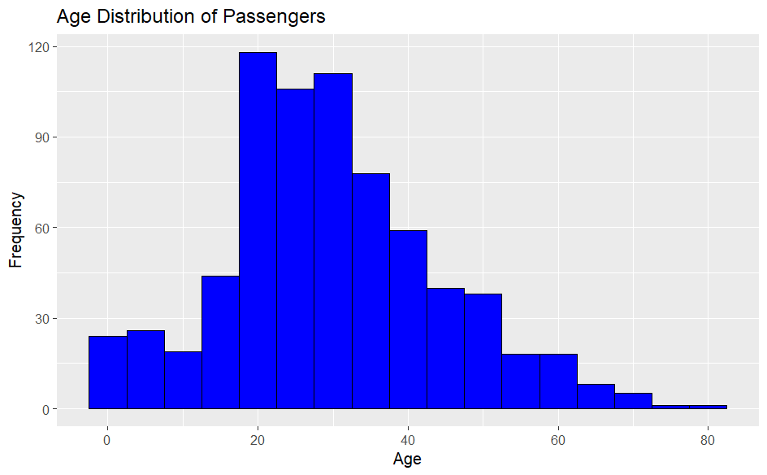

```r
age_distro <- ggplot(titanic_df, aes(x = Age)) +
  geom_histogram(binwidth = 5, fill = "blue", color = "black") +
  labs(title = "Age Distribution of Passengers", x = "Age", y = "Frequency")

age_distro

ggsave("age_distro.png", plot = age_distro, width = 6, height = 4 )
```

mean age

```r
mean_age <- mean(titanic_df$Age[titanic_df$Age > 0])

print(paste("Mean Age (excluding Zeros): ", mean_age))
```

```
[1] "Mean Age (excluding Zeros):  29.6991176470588"
```

What is the correlation between age and survival: Using the stored func correlation tests, we will be able to see whether age influenced survival.

```r
age_and_survival <- cor.test(titanic_df$Age, titanic_df$Survived, use = "complete.obs")

age_and_survival
```

```
    Pearson's product-moment correlation

data:  titanic_df$Age and titanic_df$Survived
t = 0.31426, df = 889, p-value = 0.7534
alternative hypothesis: true correlation is not equal to 0
95 percent confidence interval:
 -0.05517638  0.07616390
sample estimates:
       cor
0.01053922
```

ANALYSIS Here we find that the correlation co-efficient is 0.01053922, which is very close to 0. This indicates a very weak linear relationship between age and survival.

Secondly, we also find that the p-value is 0.7534, which is greater than the typical significance level of 0.05. This will mean that we fail to reject the null hypothesis that the true correlation is equal to 0. In other words, the results do not provide strong evidence of a significant correlation between age and survival.

Hence, with the 95 percent confidence interval ranges from -0.05517638 to 0.07616390, we can say that there is no significant relationship between age and survival. People who survived could have been very young, or old.

With that, was there a relation between the passenger’s age and passenger class? My guess is that older passengers were more likely to travel 1st class as compared to younger ones.

```r
relation_passenger_v_class <- cor.test(titanic_df$Age, titanic_df$Pclass, use = "complete.obs")

relation_passenger_v_class
```

```
    Pearson's product-moment correlation

data:  titanic_df$Age and titanic_df$Pclass
t = -11.555, df = 889, p-value < 2.2e-16
alternative hypothesis: true correlation is not equal to 0
95 percent confidence interval:
 -0.4171310 -0.3028636
sample estimates:
       cor
-0.3613532
```

ANALYSIS: First, the correlation co-efficient is -0.3613532. This means that there is a slight negative correlation between passenger’s age and passenger class. This then suggests that as the passenger’s age increases, the passenger class decreases. Thus, older people went for 1st class or even 2nd class..

Secondly, The p-value is less than 2.2e-16, which is much smaller than the typical significance level of 0.05. In other words, the results provide strong evidence of a significant correlation between age and passnger class.

The 95 percent confidence interval ranges from -0.4171310 to -0.3028636. Since this interval does not include 0, it supports the finding that there is a significant correlation between age and passenger class.

Hence, we can say that there is a significant negative correlation between the passenger’s age and passenger class in the Titanic dataset. This suggests that older passengers were more likely to travel in higher classes (1st class) compared to younger passengers. However, can we say that people who flew first class had higher chance of survival?

Knowing that correlation is not causation, I will explore further.

what was the distribution of survival by age?

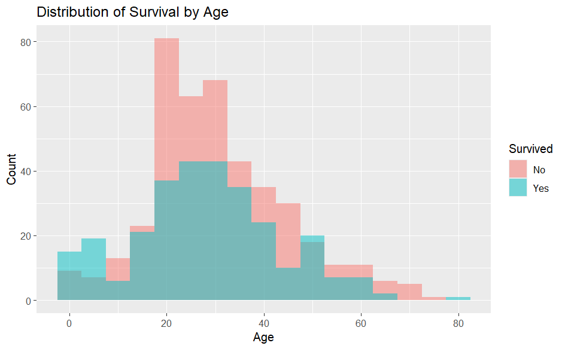

```r
titanic_df <- titanic_df[titanic_df$Age != "N/A" & titanic_df$Age > 0, ]

# Convert Age column to numeric
titanic_df$Age <- as.numeric(titanic_df$Age)

# Create a histogram of Age, colored by Survived
survival_v_age_distro <- ggplot(titanic_df, aes(x = Age, fill = factor(Survived))) +
  geom_histogram(binwidth = 5, alpha = 0.5, position = 'identity') +
  scale_fill_discrete(name = "Survived", labels = c("No", "Yes")) +
  labs(title = "Distribution of Survival by Age", x = "Age", y = "Count")

survival_v_age_distro

ggsave("survival_v_age_distro.png", plot = survival_v_age_distro, width = 6, height = 4)
```

Secondly, It looks like age is a factor for survival here, as younger people had better survival rates.

There were fewer survivors above age 40. This suggests a lower survival rates for older passengers.

Was there a higher survival rate among passengers in the upper classes?

```r
 #omit the null values
titanic_df[titanic_df == "N/A"] <- NA

# Calculate survival rate by passenger class
survival_rate_by_class <- titanic_df %>%
  group_by(Pclass) %>%
  summarise(Survival_rate = mean(Survived, na.rm = TRUE))

# Print the survival rate by passenger class
print(survival_rate_by_class)
```

| Pclass | Survival_rate |
| --- | --- |
| 1 | 0.6559140 |
| 2 | 0.4797688 |
| 3 | 0.2394366 |

```r
NA
```

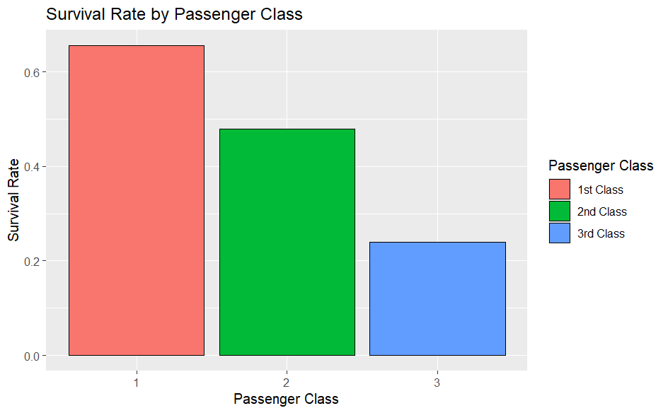

```r
# Create a bar plot of Survival Rate by Passenger Class
survival_rate <- ggplot(survival_rate_by_class, aes(x = factor(Pclass), y = Survival_rate, fill = factor(Pclass))) +
  geom_bar(stat = "identity", color = "black") +
  scale_fill_discrete(name = "Passenger Class", labels = c("1st Class", "2nd Class", "3rd Class")) +
  labs(title = "Survival Rate by Passenger Class", x = "Passenger Class", y = "Survival Rate")

survival_rate

ggsave("survival_rate_pclass_distro.png", plot = survival_rate, width = 6, height = 4)
```

ANALYSIS:

The rate of survival were 06, 0.5, 0.25 for 1st , 2nd, and 3rd class respectively. This indicates that passengers in higher classes had a better chance of survival, especially at 1st class.

What was the age distribution within each passenger class?

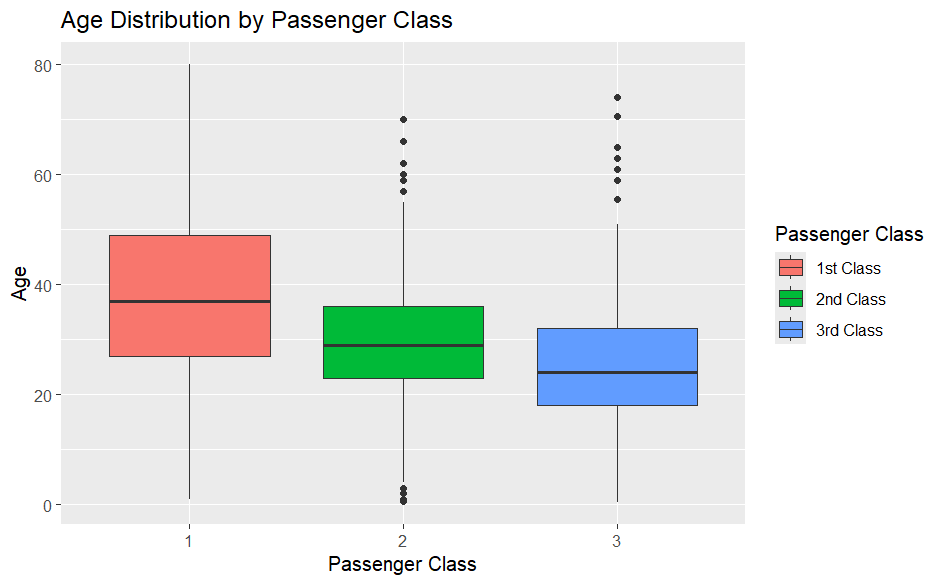

```r
# omit 0 ages
titanic_df <- titanic_df[titanic_df$Age != "N/A" & titanic_df$Age > 0, ]


titanic_df$Age <- as.numeric(titanic_df$Age) # Convert Age column to numeric

# Create a boxplot of Age by Passenger Class
age_v_pclass <- ggplot(titanic_df, aes(x = factor(Pclass), y = Age, fill = factor(Pclass))) +
  geom_boxplot() +
  scale_fill_discrete(name = "Passenger Class", labels = c("1st Class", "2nd Class", "3rd Class")) +
  labs(title = "Age Distribution by Passenger Class", x = "Passenger Class", y = "Age")

age_v_pclass

ggsave("age_v_pclass.png", plot = age_v_pclass, width = 6, height = 4)
```

Here we can see that the red box, representing the age range for 1st class has a higher median range and a wider age range. Secondly, the green box, has a slightly lower median age than 1st class and a narrower age range. then, the blue box shows the lowest median age and a similar age range to 2nd class. with this it seems that 1st class passengers were generally older than those in the 2nd and 3rd.

what was the average age of male and female passengers?

```r
# Filter out "N/A" values
# then Convert Age column to numeric
#calc the mean age

titanic_df_male <- titanic_df[titanic_df$Sex == "male" & titanic_df$Age != "N/A", ]
titanic_df_female <- titanic_df[titanic_df$Sex == "female" & titanic_df$Age != "N/A", ]

#to num
titanic_df_male$Age <- as.numeric(titanic_df_male$Age)
titanic_df_female$Age <- as.numeric(titanic_df_female$Age)

# Calculate the mean age
average_age_male <- mean(titanic_df_male$Age)
average_age_female <- mean(titanic_df_female$Age)

# Print the mean age
print(paste("Average Age of Male Passengers: ", average_age_male))
print(paste("Average Age of Female Passengers: ", average_age_female))
```

[output not shown]

Let’s test some hypothesis

Calculate the number of passengers traveling alone versus with family

```r
# Create a new column 'Family_size'
#then

titanic_df$Family_size <- titanic_df$SibSp + titanic_df$Parch

# Calculate the number of passengers traveling alone and with family
num_alone <- sum(titanic_df$Family_size == 0)
num_with_family <- sum(titanic_df$Family_size > 0)

print(paste("Number of Passengers Traveling Alone: ", num_alone))
```

```
[1] "Number of Passengers Traveling Alone:  404"
```

```r
print(paste("Number of Passengers Traveling with Family: ", num_with_family))
```

```
[1] "Number of Passengers Traveling with Family:  310"
```

CONCLUSION:

There was however a moderate negative correlation between age and passenger class, suggesting that older passengers were more likely to be in higher classes.

Then the age distribution varied across passenger classes, with older passengers more likely to be in higher classes.